# Data Analysis Report

Niklas Johannes

10/2/2019

```r
# pacman makes it easier to load and install packages
if (!requireNamespace("pacman"))
  install.packages("pacman")

library(pacman)

# load packages
p_load(
  knitr,
  MASS,
  Matrix,
  mgcv,
  Rmisc,
  here,
  DT,
  cowplot,
  pastecs,
  lme4,
  afex,
  tidyverse
)

# set seed
set.seed(42)

# set theme for ggplot
theme_set(theme_cowplot())
```

Below the custom functions I’ll be using throughout the script.

```r
### FUNCTION 1 ###
# function that transforms feet and inches to cm
feet_inches_to_cm <-
  function(feet, inches){
    feet_to_cm <- feet * 30.48
    inches_to_cm <- inches * 2.54
    cm <- feet_to_cm + inches_to_cm
    cm <- round(cm, digits = 0)

    return(cm)
  }

### FUNCTION 2 ###
# function that transforms stones and pounds to kg
stones_pounds_to_kg <-
  function(pounds, stones=NULL){
    if(missing(stones)){
      pounds_to_kg <- pounds * 0.453592
      kg <- pounds_to_kg
      kg <- round(kg, digits = 0)

      return(kg)
    }
    else{
      stones_to_kg <- stones * 6.35029
      pounds_to_kg <- pounds * 0.453592
      kg <- stones_to_kg + pounds_to_kg
      kg <- round(kg, digits = 0)

      return(kg)
    }
  }

### FUNCTION 3 ###
# function that gives summary statistics and a densityplot, with different levels of repeated vs. trait-like measures
describe_visualize <-
  function(df,
           variable,
           repeated_measure = FALSE,
           want_summary = FALSE){

    variable <- enquo(variable)

    # specifies whether the variable we want to plot is a trait-like or repeated measure
    if (repeated_measure == FALSE){
      df <-
        df %>%
        group_by(pp) %>%
        slice(1) %>%
        ungroup()
    } else {
      df <-
        df
    }

    # descriptive stats
    sum_stats <-
      df %>%
      pull(!! variable) %>%
      stat.desc()

    # plot
    plot <-
      ggplot(df, aes(x = !! variable)) +
        geom_density(color = "darkgrey", fill = "darkgrey") +
        geom_point(aes(x = !! variable, y = 0))

    # return the two (if both are wanted)
    if(want_summary == TRUE){
      return(list(kable(sum_stats), plot))
    } else{
      return(plot)
    }
  }

### FUNCTION 4 ###
# function that returns a table for trait-like categorical variables
my_table <-
  function(df, variable){
    variable <- enquo(variable)

    df %>%
      group_by(pp) %>%
      slice(1) %>%
      pull(!! variable) %>%
      table()
  }

### FUNCTION 5 ###
# raincloud plot function from https://github.com/RainCloudPlots/RainCloudPlots/blob/master/tutorial_R/R_rainclouds.R
# Defining the geom_flat_violin function ----
# Note: the below code modifies the
# existing github page by removing a parenthesis in line 50

"%||%" <- function(a, b) {
  if (!is.null(a)) a else b
}

geom_flat_violin <- function(mapping = NULL, data = NULL, stat = "ydensity",
                             position = "dodge", trim = TRUE, scale = "area",
                             show.legend = NA, inherit.aes = TRUE, ...) {
  layer(
    data = data,
    mapping = mapping,
    stat = stat,
    geom = GeomFlatViolin,
    position = position,
    show.legend = show.legend,
    inherit.aes = inherit.aes,
    params = list(
      trim = trim,
      scale = scale,
      ...
    )
  )
}

#' @rdname ggplot2-ggproto
#' @format NULL
#' @usage NULL
#' @export
GeomFlatViolin <-
  ggproto("GeomFlatViolin", Geom,
    setup_data = function(data, params) {
      data$width <- data$width %||%
        params$width %||% (resolution(data$x, FALSE) * 0.9)

      # ymin, ymax, xmin, and xmax define the bounding rectangle for each group
      data %>%
        group_by(group) %>%
        mutate(
          ymin = min(y),
          ymax = max(y),
          xmin = x,
          xmax = x + width / 2
        )
    },

    draw_group = function(data, panel_scales, coord) {
      # Find the points for the line to go all the way around
      data <- transform(data,
        xminv = x,
        xmaxv = x + violinwidth * (xmax - x)
      )

      # Make sure it's sorted properly to draw the outline
      newdata <- rbind(
        plyr::arrange(transform(data, x = xminv), y),
        plyr::arrange(transform(data, x = xmaxv), -y)
      )

      # Close the polygon: set first and last point the same
      # Needed for coord_polar and such
      newdata <- rbind(newdata, newdata[1, ])

      ggplot2:::ggname("geom_flat_violin", GeomPolygon$draw_panel(newdata, panel_scales, coord))
    },

    draw_key = draw_key_polygon,

    default_aes = aes(
      weight = 1, colour = "grey20", fill = "white", size = 0.5,
      alpha = NA, linetype = "solid"
    ),

    required_aes = c("x", "y")
  )

### FUNCTION 6 ###
# creates raincloud plots
rc_plot <-
  function(
    df,
    measurement,
    variable,
    group,
    xlab,
    title,
    facet = NULL
  ) {
    rc_plot <-
    ggplot(
      df %>%
        filter(measure == measurement),
      aes_string(
        x = group,
        y = variable,
        fill = group,
        color = group
      )
    ) +
      geom_flat_violin(position = position_nudge(x = .2,
                                                 y = 0),
                       adjust = 2) +
      geom_point(position = position_jitter(width = .15),
                 size = .10) +
      ylab("Rating (0-100)") +
      xlab(xlab) +
      coord_flip() +
      guides(fill = FALSE,
             color = FALSE) +
      scale_color_brewer(palette = "Dark2") +
      scale_fill_brewer(palette = "Dark2") +
      ggtitle(title)

    if(!is.null(facet)){
      rc_plot <-
      rc_plot +
        facet_wrap(facet)
    }

    return(rc_plot)
  }

### FUNCTION 6 ###
# creates line plots
line_plot <-
  function(
    df,
    x_group,
    measure,
    group_by
  ) {

    measure <- enquo(measure)

    ggplot(df,
           aes_string(
             x = x_group,
             y = measure,
             group = group_by,
             color = group_by,
             linetype = group_by
           )
    ) +
      geom_line() +
      geom_point() +
      geom_errorbar(
        aes(
          ymin = !! measure - se,
          ymax = !! measure + se),
        width = .05) +
      scale_color_brewer(palette = "Dark2")
  }
```

# 1. Load and wrangle data

## 1.1 Load data

```r
headers <- read_csv(
  here('data', 'raw_data.csv'),
  col_names = FALSE,
  n_max = 1) %>%
  as.character() # variable names stored in a vector

raw_data <- read_csv(
  here('data', 'raw_data.csv'),
  col_names = headers, # use that name vector here to name variables
  na = "",
  skip = 3 # those are the three rows that contain the variable info
  )

rm(headers) # clear names from workspace
```

The data frame is extremely wide; we have 854 variables. This has several reasons:

- Qualtrics data are generally in the wide format, so each stimulus gets a column rather than a row
- What label type was assigned to which food type for attractiveness ratings was counterbalanced, such that there were two sets, each containing 40 variables (= 80 total)
- Participants only answered one set, but both sets are contained in the data, meaning that participants will have entries for one set of variables, but only NA for the other set
- Each stimulus was timed, meaning Qualtrics measured four additional variables per stimulus: first click, last click, number of clicks, and after how much time the page was submitted
- This means in addition to the 80 stimulus variables, there are 80 (the two sets) x 4 (timing variables) = 320 variables just for attractiveness ratings (total 400 attractiveness variables)
- This entire procedure also applies to simulation ratings, doubling the number of stimulus rating variables (800 total rating variables)
- The remaining 54 are demographic etc. variables

## 1.2 Wrangling

We need to get these data into the long format. Before that, let’s only keep those variables we need and simultaneously give them proper names. Also, the `response_id` already is a unique identifier, but not easy to read. I’ll add a participant number (`pp`). Last, because I’m cleaning the raw data, I’ll use a new data object: `working_file`

```r
working_file <-
  raw_data %>%
  select(
    start_date = StartDate,
    end_date = EndDate,
    duration = `Duration (in seconds)`,
    finished = Finished,
    response_id = ResponseId,
    fullfil_criteria = Q3,
    consent = Q8,
    prolific_id = Q9,
    group = Group,
    hungry = Q11_1,
    thirsty = Q11_2,
    desire_instructions_time = `Q13_Page Submit`,
    pb_1_c_attr_1:`mb_20_enh_attr_time_Click Count`, # all attractiveness variables
    simulations_instructions_time = `Q41_Page Submit`,
    pb_1_c_sim_1:`mb_20_enh_sim_time_Click Count`, # all simulation variables
    age = Q19,
    gender = Q20,
    height_choice = Q21,
    height_cm = Q22_1,
    height_feet = Q23_1,
    height_inches = Q23_2,
    weight_choice = Q24,
    weight_kilos = Q25_1,
    weight_stones = Q26_1,
    weight_pounds = Q26_2,
    weight_pounds_only = Q27_1,
    diet = Q28,
    diet_details = Q29,
    meat_per_week = Q30,
    change_diet = Q31_1,
    attitude_meat = attitude_meat_1,
    attitude_vegan = attitude_vegan_1,
    attitude_pb = attitude_pb_1,
    allergies = Q32,
    allergies_details = Q33,
    language_issues = Q34,
    language_issues_details = Q35,
    didnt_like = Q36,
    study_about = Q37,
    technical_issues = Q38,
    -contains("Click"), # omit click count variables
  ) %>%
  mutate(pp = paste0("pp_", row_number())) %>%
  select(# add participant number and set it as first column
    pp,
    everything()
  )
```

Next, I assign the correct variable type. In addition, I exported the Qualtrics data with numbers as output, so I will reintroduce the factor levels for factor variables.

```r
working_file <-
  working_file %>%
  mutate_at(
    vars(
      pp,
      finished,
      response_id:group,
      gender,
      height_choice,
      weight_choice,
      diet,
      allergies,
      language_issues
    ),
    list(~ as.factor(.))
  ) %>%
  mutate(
    finished = fct_recode(
      finished,
      no = "0",
      yes = "1"
    ),
    gender = fct_recode(
      gender,
      male = "1",
      female = "2",
      other = "3"
    ),
    diet = fct_recode(
      diet,
      omnivore = "1",
      pescatarian = "2",
      vegetarian = "3",
      vegan = "4",
      other = "5"
    ),
    height_choice = fct_recode(
      height_choice,
      cm = "1",
      feet_inches = "2"
    ),
    weight_choice = fct_recode(
      weight_choice,
      kg = "1",
      stones_pounds = "2",
      pounds_only = "3"
    )
  ) %>%
  mutate_at(
    vars(
      fullfil_criteria,
      consent,
      allergies,
      language_issues
    ),
    list(
      ~ fct_recode(
        .,
        yes = "1",
        no = "2"
      )
    )
  )
```

Upon inspection, I saw that meat eating frequency (`meat_per_week`) has two non-numerical entries: `1/2` and `less than once`. I don’t want to remove the latter, so I’ll convert both to a number (0.5).

```r
working_file <-
  working_file %>%
  mutate(
    meat_per_week = case_when(
      meat_per_week %in% c("1/2", "less than once") ~ 0.5,
      TRUE ~ as.numeric(meat_per_week)
    )
  )
```

Similarly, there are text entries in `weight_kilos` and `weight_pounds`. In `weight_kilos` there’s a text entry explaining that the respondent doesn’t know their weight, so we’ll set that to NA. In `weight_pounds`, the respondent indicated stones, but `"N/A"` for pounds, so we’ll set that to 0, assuming the respondent weighed around the indicated weight in stones. We’ll do the same for all those who only provided stones, but no pounds.

```r
working_file <-
  working_file %>%
  mutate(
    weight_kilos = as.numeric(
      na_if(weight_kilos, "I don't lnow unfortuantely and I do not have acces to a set of scales qhilw filling out this survey. I applogise for this, but I was not informed I would need this prior to starting the survey.")
    ),
    weight_pounds = as.numeric(
      na_if(weight_pounds, "N/A")
    ),
    weight_pounds = case_when(
      weight_choice == "stones_pounds" & is.na(weight_pounds) ~ 0,
      TRUE ~ weight_pounds
    )
  )
```

Because the study was conducted in the UK, we also need to transform height and weight to cm and kg, respectively.

```r
working_file <-
  working_file %>%
  mutate(
    height_cm = case_when(
      height_choice == "cm" ~ height_cm,
      height_choice == "feet_inches" ~ feet_inches_to_cm(height_feet, height_inches)
    ),
    weight_kilos = case_when(
      weight_choice == "kg" ~ weight_kilos,
      weight_choice == "stones_pounds" ~ stones_pounds_to_kg(weight_pounds, weight_stones),
      weight_choice == "pounds_only" ~ stones_pounds_to_kg(weight_pounds_only)
    )
  )
```

Now that the data are cleaned, I can finally transform them to the long format. Currently, the measurements of attractiveness and simulations are in the following format: **pb_1_c_attr_1**. The components (separated by underscores) of that format mean:

- **food type**: pb (plant-based) or mb(meat-based)
- **stimulus number**
- **label type**: c (control) or enh (enhanced)
- **measurement/DV**: attr (attractiveness) or sim (simulations)
- meaningless Qualtrics appendix: always `_1`

Let’s remove the `_1` at the end of those variable names, and also rename all `Page Submit` appendices from their variable names.

```r
working_file <-
  working_file %>%
  rename_at(
    vars(
      ends_with("_1"),
    ),
    list(
      ~ str_sub(
        ., 1, str_length(.)-2
      )
    )
  ) %>%
  rename_at(
    vars(
      ends_with("Page Submit")
    ),
    list(
      ~ str_replace(
        ., "_Page Submit", ""
      )
    )
  )
```

## 1.3 Tidy data

Let’s get to turning the data into the long format. Because we used two sets of stimuli (counterbalancing what stimulus belongs to what food type and label type), half of the participants gave responses to half of the measurement variables; the other half of participant gave responses to the other half.

Therefore, participants will have missing values on those variables that belonged to the other set (i.e., the other counterbalancing condition). Luckily, the `pivot_longer` function is amazing, so we can drop those measurements per participants with the `values_drop_na` argument.

```r
working_file <-
  working_file %>%
  pivot_longer(
    cols = c(contains("pb_"), contains("mb_")),
    names_to = c( # specifict the variables to be formed from the current variable names
      "food_type",
      "stimulus_no",
      "label_type",
      "measure"
      ),
    values_to = c( # the values, which will be measurement type (attractiveness vs. simulations) and the timer per variable
      "rating",
      "time"
      ),
    names_sep = "_",
    values_drop_na = TRUE # do not include empty entries due to counterbalancing as rows in the long format
  ) %>%

  # give proper variable names, labels, and variable types
  mutate(
    stimulus_no = as.numeric(stimulus_no)
  ) %>%
  mutate(
    food_type = fct_recode(
      as.factor(food_type),
      meat_based = "mb",
      plant_based = "pb",
    ),
    label_type = fct_recode(
      as.factor(label_type),
      control = "c",
      enhanced = "enh"
    ),
    measure = fct_recode(
      as.factor(measure),
      attractiveness = "attr",
      simulations = "sim"
    )
  ) %>% # arbitrary, but I like to order the variables roughly in the order they were collected
  select(
    pp:simulations_instructions_time,
    food_type:time,
    everything()
  )
```

Alright, the data are in a tidy format. Below, I show the data of a random participant for illustration.

|  | pp | start_date | end_date | duration | finished | response_id | fullfil_criteria | consent | prolific_id | group | hungry | thirsty | desire_instructions_time | simulations_instructions_time | food_type | stimulus_no | label_type | measure | rating | time | age | gender | height_choice | height_cm | height_feet | height_inches | weight_choice | weight_kilos | weight_stones | … |
| --- | --- | --- | --- | --- | --- | --- | --- | --- | --- | --- | --- | --- | --- | --- | --- | --- | --- | --- | --- | --- | --- | --- | --- | --- | --- | --- | --- | --- | --- | --- |
| 1 | pp_100 | 2019-06-21T14:25:22Z | 2019-06-21T14:46:01Z | 1238 | yes | R_1rHATPJweuTcDyz | yes | yes | 5ce2faa752845500174611fe | 1 | 0 | 77 | 14.122 | 271.195 | plant_based | 1 | control | attractiveness | 58.59 | 4.498 | 33 | male | feet_inches | 180 | 5 | 11 | stones_pounds | 87 | 13 | … |
| 2 | pp_100 | 2019-06-21T14:25:22Z | 2019-06-21T14:46:01Z | 1238 | yes | R_1rHATPJweuTcDyz | yes | yes | 5ce2faa752845500174611fe | 1 | 0 | 77 | 14.122 | 271.195 | plant_based | 4 | control | attractiveness | 17.89 | 7.645 | 33 | male | feet_inches | 180 | 5 | 11 | stones_pounds | 87 | 13 | … |
| 3 | pp_100 | 2019-06-21T14:25:22Z | 2019-06-21T14:46:01Z | 1238 | yes | R_1rHATPJweuTcDyz | yes | yes | 5ce2faa752845500174611fe | 1 | 0 | 77 | 14.122 | 271.195 | plant_based | 7 | control | attractiveness | 53.8 | 7.955 | 33 | male | feet_inches | 180 | 5 | 11 | stones_pounds | 87 | 13 | … |
| 4 | pp_100 | 2019-06-21T14:25:22Z | 2019-06-21T14:46:01Z | 1238 | yes | R_1rHATPJweuTcDyz | yes | yes | 5ce2faa752845500174611fe | 1 | 0 | 77 | 14.122 | 271.195 | plant_based | 9 | control | attractiveness | 5.07 | 5.639 | 33 | male | feet_inches | 180 | 5 | 11 | stones_pounds | 87 | 13 | … |
| 5 | pp_100 | 2019-06-21T14:25:22Z | 2019-06-21T14:46:01Z | 1238 | yes | R_1rHATPJweuTcDyz | yes | yes | 5ce2faa752845500174611fe | 1 | 0 | 77 | 14.122 | 271.195 | plant_based | 12 | control | attractiveness | 20.99 | 14.74 | 33 | male | feet_inches | 180 | 5 | 11 | stones_pounds | 87 | 13 | … |
| 6 | pp_100 | 2019-06-21T14:25:22Z | 2019-06-21T14:46:01Z | 1238 | yes | R_1rHATPJweuTcDyz | yes | yes | 5ce2faa752845500174611fe | 1 | 0 | 77 | 14.122 | 271.195 | plant_based | 14 | control | attractiveness | 3.94 | 4.99 | 33 | male | feet_inches | 180 | 5 | 11 | stones_pounds | 87 | 13 | … |
| 7 | pp_100 | 2019-06-21T14:25:22Z | 2019-06-21T14:46:01Z | 1238 | yes | R_1rHATPJweuTcDyz | yes | yes | 5ce2faa752845500174611fe | 1 | 0 | 77 | 14.122 | 271.195 | plant_based | 15 | control | attractiveness | 23.94 | 7.229 | 33 | male | feet_inches | 180 | 5 | 11 | stones_pounds | 87 | 13 | … |
| 8 | pp_100 | 2019-06-21T14:25:22Z | 2019-06-21T14:46:01Z | 1238 | yes | R_1rHATPJweuTcDyz | yes | yes | 5ce2faa752845500174611fe | 1 | 0 | 77 | 14.122 | 271.195 | plant_based | 17 | control | attractiveness | 60.85 | 4.4 | 33 | male | feet_inches | 180 | 5 | 11 | stones_pounds | 87 | 13 | … |
| 9 | pp_100 | 2019-06-21T14:25:22Z | 2019-06-21T14:46:01Z | 1238 | yes | R_1rHATPJweuTcDyz | yes | yes | 5ce2faa752845500174611fe | 1 | 0 | 77 | 14.122 | 271.195 | plant_based | 19 | control | attractiveness | 58.17 | 6.055 | 33 | male | feet_inches | 180 | 5 | 11 | stones_pounds | 87 | 13 | … |
| 10 | pp_100 | 2019-06-21T14:25:22Z | 2019-06-21T14:46:01Z | 1238 | yes | R_1rHATPJweuTcDyz | yes | yes | 5ce2faa752845500174611fe | 1 | 0 | 77 | 14.122 | 271.195 | plant_based | 20 | control | attractiveness | 44.79 | 5.87 | 33 | male | feet_inches | 180 | 5 | 11 | stones_pounds | 87 | 13 | … |

[output cut: 70 more lines]

# 2. Exclusions

## 2.1 Exclude test runs

There are still three test runs left. They can easily be identified because they do not follow the Prolific ID scheme (i.e., starting with a `5`, less than 20 characters). We exclude them here.

```r
# before excluding testruns
length(unique(working_file$pp))
```

```
## [1] 178
```

```r
working_file <-
  working_file %>%
  filter(
    str_length(
      as.character(prolific_id)
      ) > 20
    )

# # after exclusion
length(unique(working_file$pp))
```

```
## [1] 175
```

Now exclude those who didn’t finish the survey.

```r
length(unique(working_file$pp))
```

```
## [1] 175
```

```r
working_file <-
  working_file %>%
  filter(finished == "yes")

length(unique(working_file$pp))
```

```
## [1] 174
```

Out of experience, Qualtrics isn’t very good at determining whether a survey is finished or not. We double check this: If indeed all participants gave all ratings, there should be 80 for each of the remaining 174 participants: 40 attractiveness ratings and 40 simulations ratings. Furthermore, there should be few `NA`s remaining on any of the ratings.

There are three cases where participants did not report a rating. I double checked that in the raw data file and that’s indeed the case. Respondents were not forced to give a response (Qualtrics option was “Request Response”), so participants simply did not respond to those three items.

```r
# does each participant have 80 ratings (i.e., rows)?
working_file %>%
  group_by(pp) %>%
  count() %>%
  ungroup() %>%
  summarize(
    all_there = sum(n == 80)
  )
```

```
## # A tibble: 1 x 1
##   all_there
##       <int>
## 1       174
```

```r
# compare to sample
length(unique(working_file$pp))
```

```
## [1] 174
```

```r
# are there NAs left on the rating or timing variable?
working_file %>%
  select(rating, time) %>%
  summarize_all(
    list(~ sum(is.na(.)))
  )
```

```
## # A tibble: 1 x 2
##   rating  time
##    <int> <int>
## 1      3     0
```

```r
working_file %>%
  filter(is.na(rating)) %>%
  DT::datatable(
  .,
  options = list(
    autoWidth = TRUE,
    scrollY = TRUE,
    scrollX = TRUE,
    pageLength = 3
  )
  )
```

|  | pp | start_date | end_date | duration | finished | response_id | fullfil_criteria | consent | prolific_id | group | hungry | thirsty | desire_instructions_time | simulations_instructions_time | food_type | stimulus_no | label_type | measure | rating | time | age | gender | height_choice | height_cm | height_feet | height_inches | weight_choice | weight_kilos | weight_stones | … |
| --- | --- | --- | --- | --- | --- | --- | --- | --- | --- | --- | --- | --- | --- | --- | --- | --- | --- | --- | --- | --- | --- | --- | --- | --- | --- | --- | --- | --- | --- | --- |
| 1 | pp_116 | 2019-06-21T14:39:54Z | 2019-06-21T14:49:44Z | 590 | yes | R_2qwm7vseqydJ0W7 | yes | yes | 5bed9805276f5b0001532993 | 1 | 67 | 67 | 3.758 | 8.944 | meat_based | 12 | enhanced | simulations |  | 3.105 | 19 | female | feet_inches | 170 | 5 | 7 | stones_pounds | 64 | 10 | … |
| 2 | pp_137 | 2019-06-21T14:43:30Z | 2019-06-21T14:53:17Z | 586 | yes | R_QchBMgK9n8zyOtP | yes | yes | 5bc3645f4c2d8f0001afe23d | 2 | 0 | 1 | 7.021 | 2.362 | meat_based | 16 | control | simulations |  | 4.894 | 21 | male | feet_inches | 188 | 6 | 2 | pounds_only | 95 |  | … |
| 3 | pp_151 | 2019-06-21T14:22:06Z | 2019-06-21T14:55:26Z | 1999 | yes | R_1IbjSHKku1Kh2lD | yes | yes | 5cfd7f37bab656000198b80b | 2 | 100 | 100 | 3.238 | 1.064 | meat_based | 19 | control | simulations |  | 5.087 | 26 | female | feet_inches | 170 | 5 | 7 | stones_pounds | 76 | 12 | … |

## 2.3 Not fulfilling inclusion criteria

There was a filter question at the beginning of the study asking participants whether they fulfill the inclusion criteria. All participants indicated they fulfilled the criteria, so no need to exclude anyone.

```r
working_file %>%
  group_by(pp) %>%
  slice(1) %>%
  pull(fullfil_criteria) %>%
  table()
```

```
## .
## yes  no
## 174   0
```

## 2.3 Identify rushed responses

In the preregistration, we specified data quality checks: if participants do not comply with the experimental instructions or give (almost) exactly the same response on each trial (i.e., within 1 of 100 scale points).

To identify possibly rushed responses, we inspect the variation of ratings and compare those to the how quickly participants responded.

The variation looks fine, nobody just clicked the same point of the scale repeatedly. One participant was extremely fast, spending about 1.5 seconds per rating, possibly hinting at randomly clicking through.

```r
# lowest variation of the ratings
working_file %>%
  group_by(pp) %>%
  summarize(
    mean = (mean(rating, na.rm = TRUE)),
    sd = sd(rating, na.rm = TRUE)
  ) %>%
  arrange(sd)
```

```
## # A tibble: 174 x 3
##    pp      mean    sd
##    <fct>  <dbl> <dbl>
##  1 pp_139  42.1  10.1
##  2 pp_47   53.2  12.2
##  3 pp_137  58.1  14.3
##  4 pp_49   82.8  14.6
##  5 pp_141  53.6  14.8
##  6 pp_140  56.4  15.4
##  7 pp_160  59.3  15.8
##  8 pp_112  55.1  16.1
##  9 pp_125  62.5  16.2
## 10 pp_30   55.3  16.4
## # ... with 164 more rows
```

```r
# check response times
time_means <-
  working_file %>%
  group_by(pp) %>%
  summarize(
    time_mean = mean(time)
  ) %>%
  arrange(time_mean)

# inspect the fastest times
head(time_means, n = 10)
```

```
## # A tibble: 10 x 2
##    pp     time_mean
##    <fct>      <dbl>
##  1 pp_81       1.54
##  2 pp_69       2.40
##  3 pp_82       2.65
##  4 pp_54       2.92
##  5 pp_117      3.19
##  6 pp_64       3.23
##  7 pp_120      3.25
##  8 pp_63       3.38
##  9 pp_137      3.39
## 10 pp_85       3.42
```

```r
# compare to median time
median(working_file$time)
```

```
## [1] 4.697
```

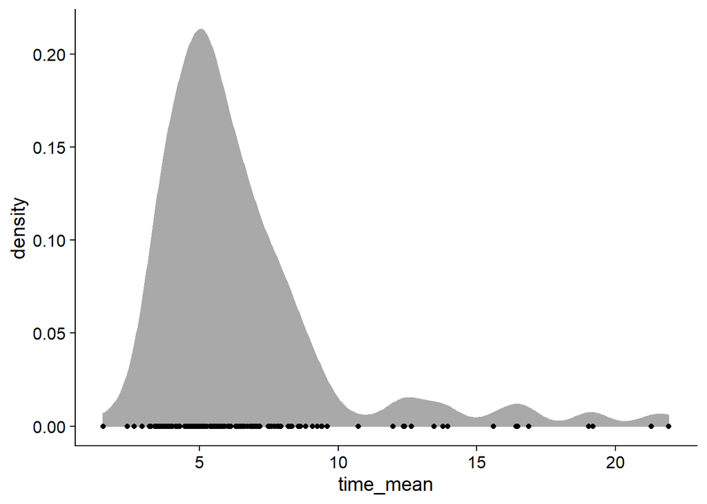

```r
# plot them
time_means %>%
  ggplot(aes(x = time_mean)) +
  geom_density(color = "darkgrey", fill = "darkgrey") +
  geom_point(aes(x = time_mean, y = 0))
```

*Note: This is not preregistered.* It’s pretty hard to tell what mean time on answering items indicates inattentiveness. However, we can at least set those mean times into relation with the sample median time. Leiner has put forward a useful way to identify meaningless data in internet studies, validated with real and simulated data.

The method is relatively straightforward: The Relative Speed Index (RSI) gives an impression of how fast participants responded to items without giving too much weight to quick or slow responses on individual stimuli. An RSI of > 1.75 is considered an indicator of meaningless data (actually, it might even be conservative).

The RSI is computed as follows:

- Compute sample’s median completion time for each page
- Divide those sample completion times by the individual respondents’ page completion time (i.e., speed factors)
- Trim these speed factors to an interval of [0|3]
- Average the trimmed speed factors per participant to obtain the RSI

```r
working_file <-
  working_file %>%

  # calculate median time for each stimulus (aka page)
  group_by(
    food_type,
    stimulus_no,
    label_type,
    measure
  ) %>%
  summarize(
    page_time_median = median(time)
  ) %>%

  # add those median page times to the data set and match with the stimuli there
  left_join(
    working_file,
    .,
    by = c(
      "food_type",
      "stimulus_no",
      "label_type",
      "measure"
    )
  ) %>%

  # now divide the median page completion time by the individual page completion time (so per row)
  mutate(
    speed_factor = page_time_median / time
  ) %>%

  # trim to [0|3]: dividing by zero will yield a speed factor of Inf, anything else a higher number
  mutate(
    speed_factor_trimmed = case_when(
      speed_factor == Inf ~ 0,
      speed_factor > 3 ~ 3,
      TRUE ~ speed_factor
    )
  ) %>%

  # average those trimmed speed factors to obtain RSI
  group_by(pp) %>%
  mutate(
    rsi = mean(speed_factor_trimmed)
  ) %>%
  ungroup()
```

Let’s inspect the RSI. Indeed, there is at least one massive outlier, and several RSIs > 1.75. If we inspect mean completion time side by side with RSI, we see that several of those participants we suspected rushed through also come up here. We thus exclude those participants with an RSI > 1.75. **Note: this decision was not preregistered, but we logged it in a decision log file.**

I’ll run the analyses with and without these 8 cases, so I’ll put their data into a separate object.

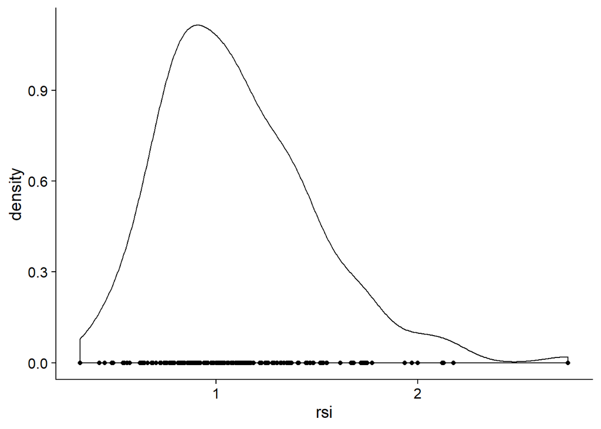

```r
# let's plot them
working_file %>%
  group_by(pp) %>%
  slice(1) %>%
  ggplot(aes(x = rsi)) +
  geom_density() +
  geom_point(aes(x = rsi, y = 0))
```

```r
# compare with raw mean time per page
working_file %>%
  group_by(pp) %>%
  slice(1) %>%
  arrange(desc(rsi)) %>%
  select(pp, rsi) %>%
  left_join(.,
            time_means,
            by = "pp"
  )
```

```
## # A tibble: 174 x 3
## # Groups:   pp [174]
##    pp       rsi time_mean
##    <fct>  <dbl>     <dbl>
##  1 pp_81   2.75      1.54
##  2 pp_116  2.18      4.02
##  3 pp_69   2.13      2.40
##  4 pp_82   2.12      2.65
##  5 pp_54   2.00      2.92
##  6 pp_118  1.97      5.24
##  7 pp_64   1.94      3.23
##  8 pp_125  1.77      3.71
##  9 pp_128  1.75      3.66
## 10 pp_137  1.74      3.39
## # ... with 164 more rows
```

```r
# how many do we exclude?
length(unique((working_file$pp))) - nrow(working_file %>% filter(rsi <= 1.75) %>% group_by(pp) %>% slice(1))
```

```
## [1] 8
```

```r
# create a separate file for those cases that we add when we test the robustness of the analysis
high_rsi <-
  working_file %>%
  filter(rsi > 1.75)

# remove them from working file
working_file <-
  working_file %>%
  filter(rsi <= 1.75)
```

# 3. Describe and visualize

## 3.1 Meta-data

How long did participants spend on the survey? Median duration is around ~ 14 minutes.

```r
describe_visualize(
  working_file,
  duration,
  FALSE,
  TRUE
)
```

```
## [[1]]
##
##
##                            x
## -------------  -------------
## nbr.val         1.660000e+02
## nbr.null        0.000000e+00
## nbr.na          0.000000e+00
## min             4.440000e+02
## max             2.513000e+03
## range           2.069000e+03
## sum             1.549810e+05
## median          8.460000e+02
## mean            9.336205e+02
## SE.mean         2.846142e+01
## CI.mean.0.95    5.619552e+01
## var             1.344687e+05
## std.dev         3.666997e+02
## coef.var        3.927717e-01
##
## [[2]]
```

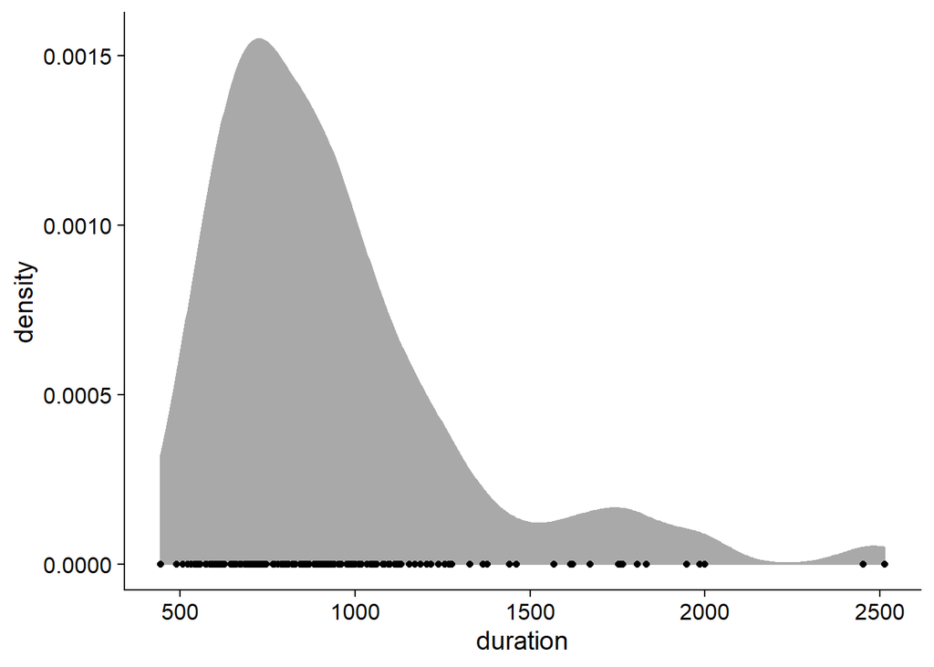

How long did they spend on the instructions for the attractiveness and simulations, respectively? Overall not long (~ 10 seconds), but some apparently left the browser window open for quite some time.

```r
describe_visualize(
  working_file,
  desire_instructions_time,
  FALSE,
  TRUE
)
```

```
## [[1]]
##
##
##                            x
## -------------  -------------
## nbr.val          166.0000000
## nbr.null           0.0000000
## nbr.na             0.0000000
## min                0.8990000
## max               53.7550000
## range             52.8560000
## sum             1854.5210000
## median             8.7835000
## mean              11.1718133
## SE.mean            0.6508350
## CI.mean.0.95       1.2850383
## var               70.3153031
## std.dev            8.3854221
## coef.var           0.7505874
##
## [[2]]
```

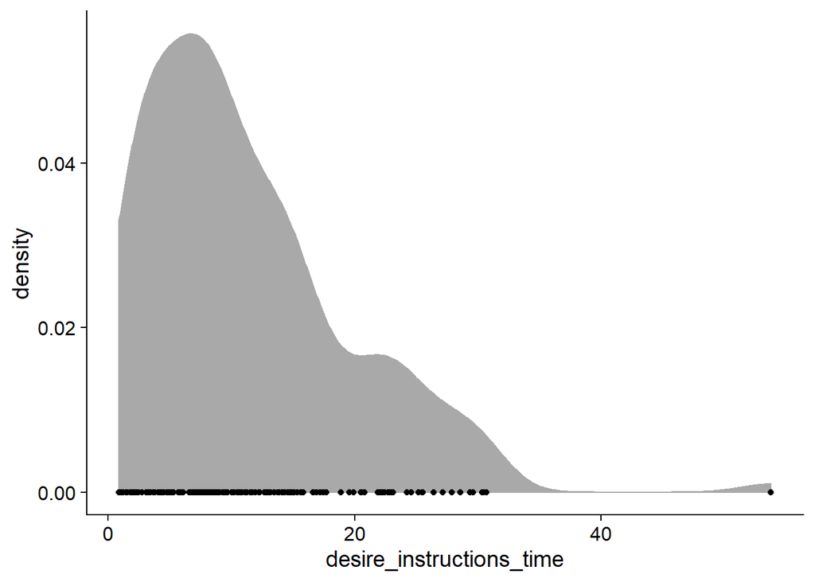

```r
describe_visualize(
  working_file,
  simulations_instructions_time,
  FALSE,
  TRUE
)
```

```
## [[1]]
##
##
##                           x
## -------------  ------------
## nbr.val          166.000000
## nbr.null           0.000000
## nbr.na             0.000000
## min                1.064000
## max              368.953000
## range            367.889000
## sum             2943.293000
## median            11.281500
## mean              17.730681
## SE.mean            2.776208
## CI.mean.0.95       5.481473
## var             1279.417335
## std.dev           35.768944
## coef.var           2.017348
##
## [[2]]
```

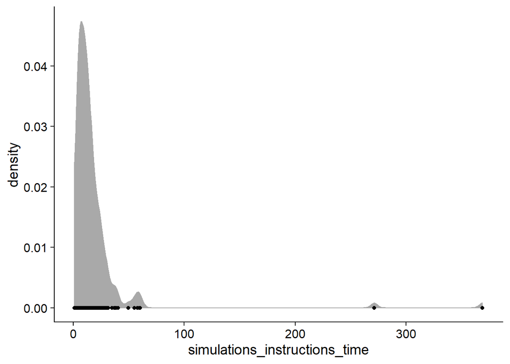

Were there language issues? Barely, and the qualitative answers don’t give cause for concern.

```r
my_table(working_file, language_issues)
```

```
## .
## yes  no
##   2 164
```

```r
working_file %>%
  group_by(pp) %>%
  slice(1) %>%
  ungroup() %>%
  filter(language_issues == "yes") %>%
  pull(language_issues_details)
```

```
## [1] "I didn't know the meaning of a few words"
## [2] "a couple words I was unsure of, like ragu"
```

## 3.2 Demographic information

First, I look at hunger and thirst ratings. Participants seemed to be more thirsty than hungry.

```r
describe_visualize(
  working_file,
  hungry,
  FALSE,
  TRUE
)
```

```
## [[1]]
##
##
##                            x
## -------------  -------------
## nbr.val          166.0000000
## nbr.null          29.0000000
## nbr.na             0.0000000
## min                0.0000000
## max              100.0000000
## range            100.0000000
## sum             4744.0000000
## median            23.0000000
## mean              28.5783133
## SE.mean            1.9521333
## CI.mean.0.95       3.8543811
## var              632.5968602
## std.dev           25.1514783
## coef.var           0.8800897
##
## [[2]]
```

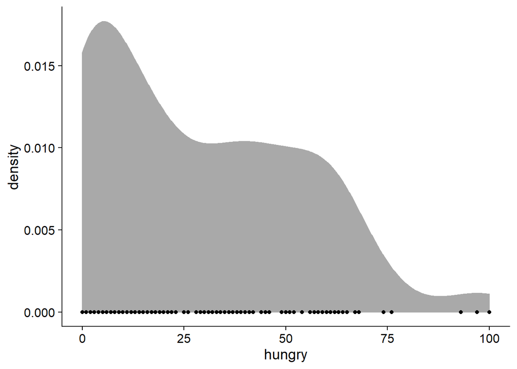

```r
describe_visualize(
  working_file,
  thirsty,
  FALSE,
  TRUE
)
```

```
## [[1]]
##
##
##                           x
## -------------  ------------
## nbr.val          166.000000
## nbr.null          10.000000
## nbr.na             0.000000
## min                0.000000
## max              100.000000
## range            100.000000
## sum             7564.000000
## median            51.000000
## mean              45.566265
## SE.mean            1.963437
## CI.mean.0.95       3.876699
## var              639.944067
## std.dev           25.297116
## coef.var           0.555172
##
## [[2]]
```

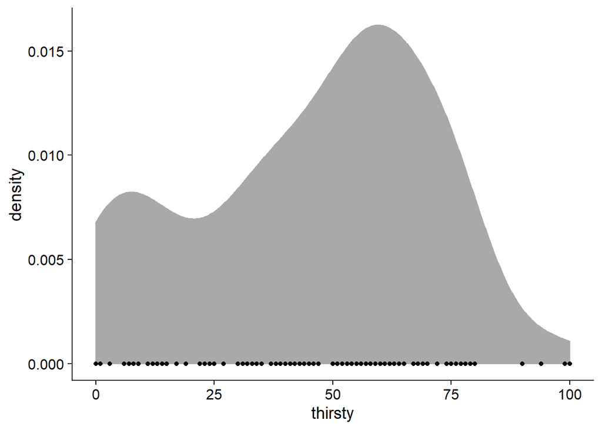

What’s the age range in our sample? One participant indicated to be 259 years old. Probably a typo, but not sure whether it’s supposed to be 25 or 59, so I set that value to `NA`.

```r
describe_visualize(
  working_file,
  age,
  FALSE,
  TRUE
)
```

```
## [[1]]
##
##
##                           x
## -------------  ------------
## nbr.val          166.000000
## nbr.null           0.000000
## nbr.na             0.000000
## min               18.000000
## max              259.000000
## range            241.000000
## sum             5353.000000
## median            30.000000
## mean              32.246988
## SE.mean            1.581207
## CI.mean.0.95       3.122006
## var              415.035597
## std.dev           20.372422
## coef.var           0.631762
##
## [[2]]
```

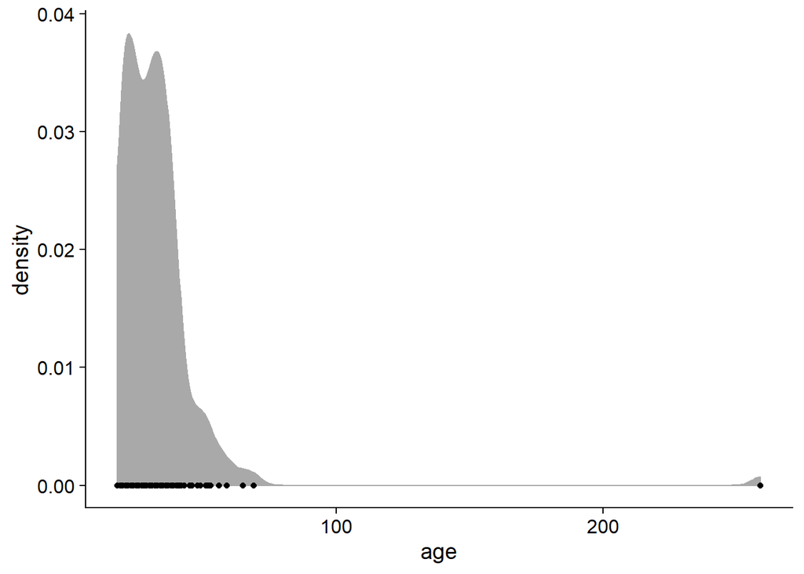

```r
working_file <-
  working_file %>%
  mutate(
    age = if_else(age == 259, NA_real_, age)
  )

describe_visualize(
  working_file,
  age,
  FALSE,
  TRUE
)
```

```
## [[1]]
##
##
##                            x
## -------------  -------------
## nbr.val          165.0000000
## nbr.null           0.0000000
## nbr.na             1.0000000
## min               18.0000000
## max               69.0000000
## range             51.0000000
## sum             5094.0000000
## median            30.0000000
## mean              30.8727273
## SE.mean            0.7868169
## CI.mean.0.95       1.5535972
## var              102.1483370
## std.dev           10.1068460
## coef.var           0.3273713
##
## [[2]]
```

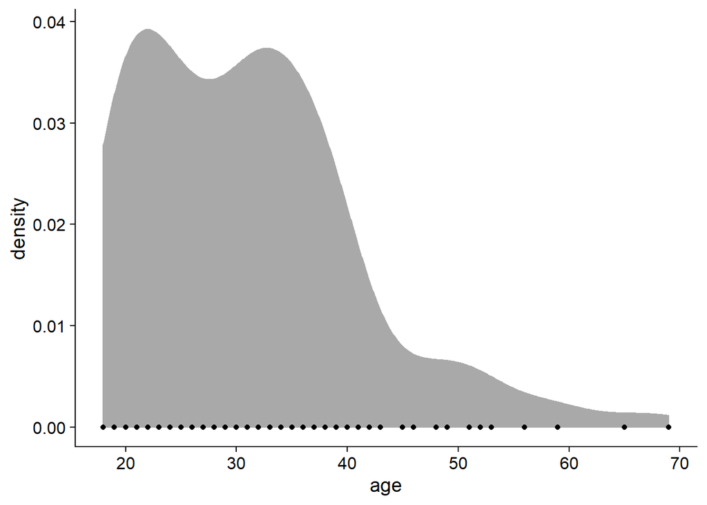

What is the gender distribution in our sample?

```r
my_table(working_file, gender)
```

```
## .
##   male female  other
##     48    117      1
```

What’s the height distribution? One participant appears to be giant. I think this is too unrealistic. We could think about whether that participant took the survey seriously, but the ratings and duration on instruction look good when inspecting the raw data. After setting that entry to missing, the rest looks pretty normal.

```r
describe_visualize(
  working_file,
  height_cm,
  FALSE,
  TRUE
)
```

```
## [[1]]
##
##
##                            x
## -------------  -------------
## nbr.val         1.650000e+02
## nbr.null        0.000000e+00
## nbr.na          1.000000e+00
## min             1.500000e+02
## max             2.900000e+02
## range           1.400000e+02
## sum             2.802400e+04
## median          1.700000e+02
## mean            1.698424e+02
## SE.mean         9.919466e-01
## CI.mean.0.95    1.958633e+00
## var             1.623531e+02
## std.dev         1.274178e+01
## coef.var        7.502120e-02
##
## [[2]]
```

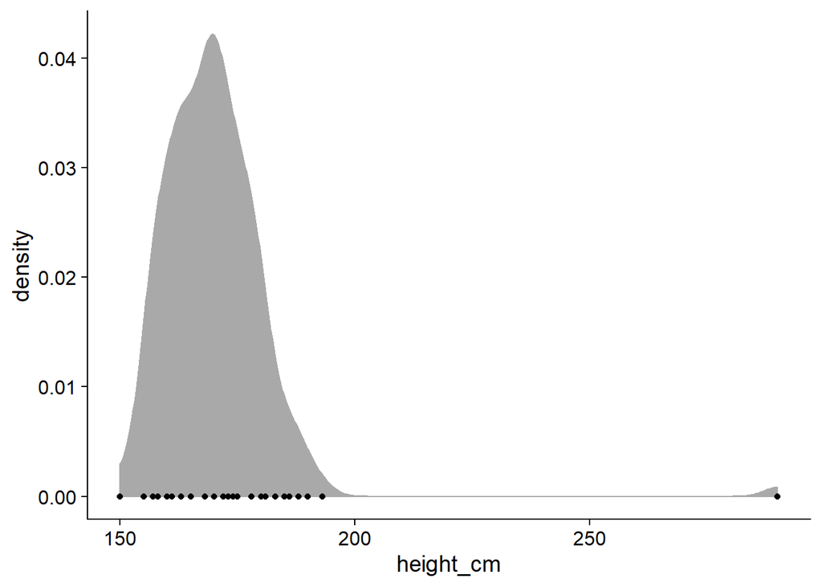

```r
working_file <-
  working_file %>%
  mutate(
    height_cm = if_else(height_cm == 290, NA_real_, height_cm)
  )

describe_visualize(
  working_file,
  height_cm,
  FALSE,
  TRUE
)
```

```
## [[1]]
##
##
##                            x
## -------------  -------------
## nbr.val         1.640000e+02
## nbr.null        0.000000e+00
## nbr.na          2.000000e+00
## min             1.500000e+02
## max             1.930000e+02
## range           4.300000e+01
## sum             2.773400e+04
## median          1.700000e+02
## mean            1.691098e+02
## SE.mean         6.727867e-01
## CI.mean.0.95    1.328501e+00
## var             7.423328e+01
## std.dev         8.615874e+00
## coef.var        5.094840e-02
##
## [[2]]
```

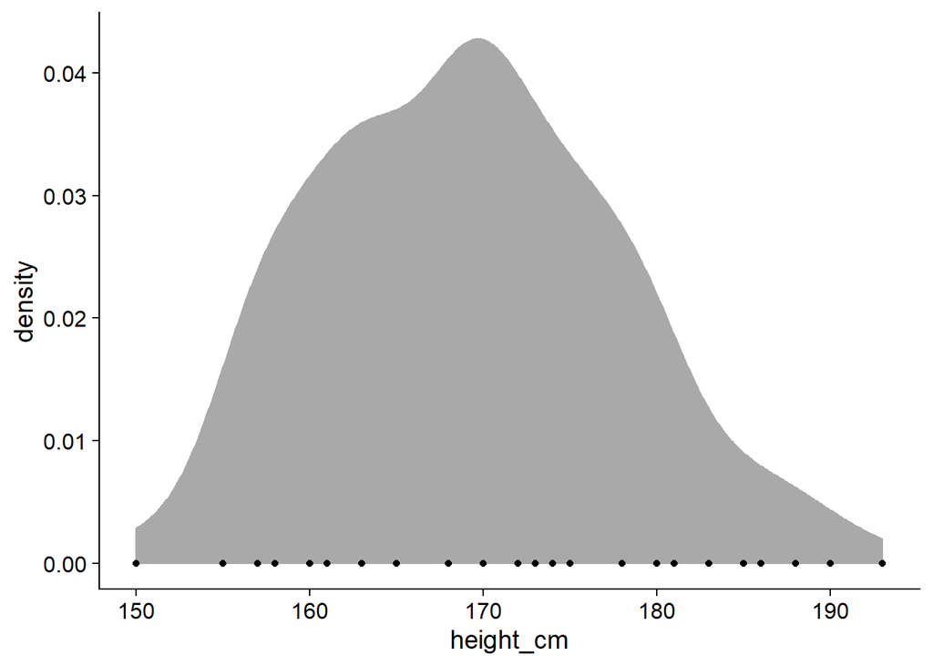

Let’s look at the weight. There’s a couple of participants who indicated to weigh less than 20 kilos. I find that hard to believe and set their weight as missing.

```r
describe_visualize(
  working_file,
  weight_kilos,
  FALSE,
  TRUE
)
```

```
## [[1]]
##
##
##                            x
## -------------  -------------
## nbr.val         1.640000e+02
## nbr.null        0.000000e+00
## nbr.na          2.000000e+00
## min             3.000000e+00
## max             1.510000e+02
## range           1.480000e+02
## sum             1.188020e+04
## median          7.000000e+01
## mean            7.244024e+01
## SE.mean         1.352381e+00
## CI.mean.0.95    2.670445e+00
## var             2.999452e+02
## std.dev         1.731893e+01
## coef.var        2.390788e-01
##
## [[2]]
```

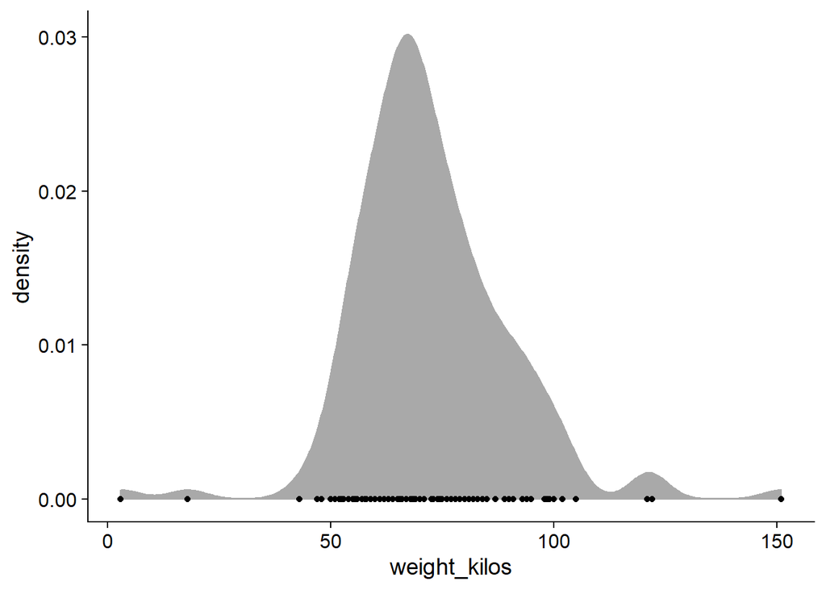

```r
working_file %>%
  filter(weight_kilos < 20) %>%
  group_by(pp) %>%
  slice(1) %>%
  ungroup() %>%
  select(pp, contains("weight"))
```

```
## # A tibble: 2 x 6
##   pp    weight_choice weight_kilos weight_stones weight_pounds
##   <fct> <fct>                <dbl>         <dbl>         <dbl>
## 1 pp_61 pounds_only              3            NA            NA
## 2 pp_90 pounds_only             18            NA            NA
## # ... with 1 more variable: weight_pounds_only <dbl>
```

```r
working_file <-
  working_file %>%
  mutate(
    weight_kilos = if_else(weight_kilos < 20, NA_real_, weight_kilos)
  )

describe_visualize(
  working_file,
  weight_kilos,
  FALSE,
  TRUE
)
```

```
## [[1]]
##
##
##                            x
## -------------  -------------
## nbr.val         1.620000e+02
## nbr.null        0.000000e+00
## nbr.na          4.000000e+00
## min             4.300000e+01
## max             1.510000e+02
## range           1.080000e+02
## sum             1.185920e+04
## median          7.000000e+01
## mean            7.320494e+01
## SE.mean         1.253943e+00
## CI.mean.0.95    2.476297e+00
## var             2.547246e+02
## std.dev         1.596009e+01
## coef.var        2.180194e-01
##
## [[2]]
```

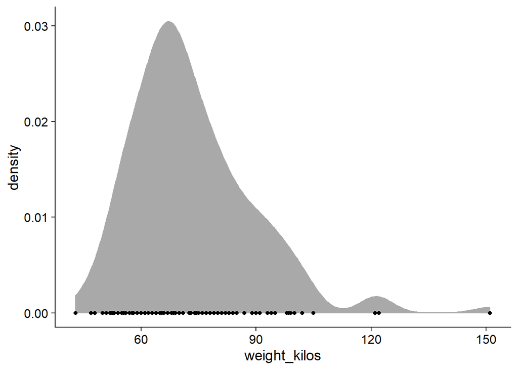

Next, some information about their diet.

- participants seem to be divided on whether they’re trying to change their diet
- frequent meat eaters
- like meat better than vegan or plant-based foods

```r
# diet
my_table(working_file, diet)
```

```
## .
##   omnivore vegetarian      other
##        163          2          1
```

```r
# how often they eat meat per week
describe_visualize(
  working_file,
  meat_per_week,
  FALSE,
  TRUE
)
```

```
## [[1]]
##
##
##                            x
## -------------  -------------
## nbr.val          166.0000000
## nbr.null           2.0000000
## nbr.na             0.0000000
## min                0.0000000
## max               21.0000000
## range             21.0000000
## sum             1155.0000000
## median             7.0000000
## mean               6.9578313
## SE.mean            0.2889093
## CI.mean.0.95       0.5704357
## var               13.8557868
## std.dev            3.7223362
## coef.var           0.5349851
##
## [[2]]
```

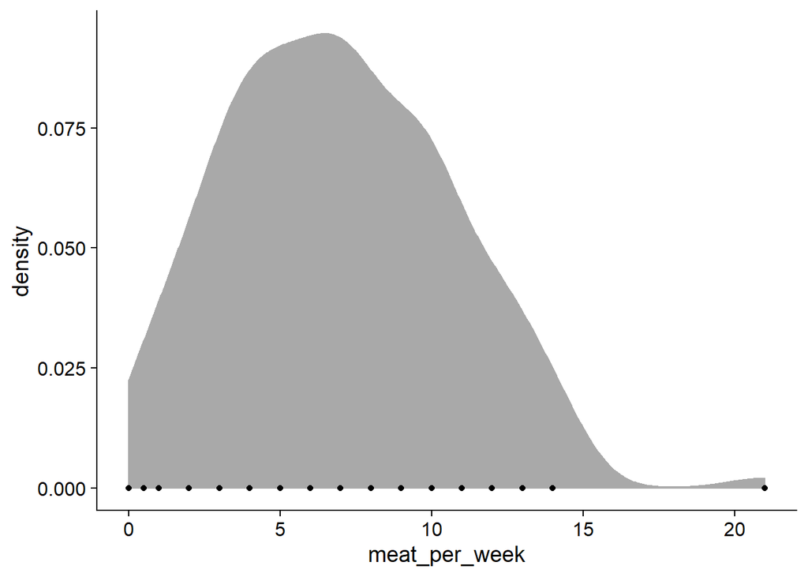

```r
# to what extent participants are currently trying to change their diets
describe_visualize(
  working_file,
  change_diet,
  FALSE,
  TRUE
)
```

```
## [[1]]
##
##
##                            x
## -------------  -------------
## nbr.val          166.0000000
## nbr.null           0.0000000
## nbr.na             0.0000000
## min                1.0000000
## max              100.0000000
## range             99.0000000
## sum             7449.8000000
## median            55.4500000
## mean              44.8783133
## SE.mean            2.6610126
## CI.mean.0.95       5.2540246
## var             1175.4439765
## std.dev           34.2847485
## coef.var           0.7639491
##
## [[2]]
```

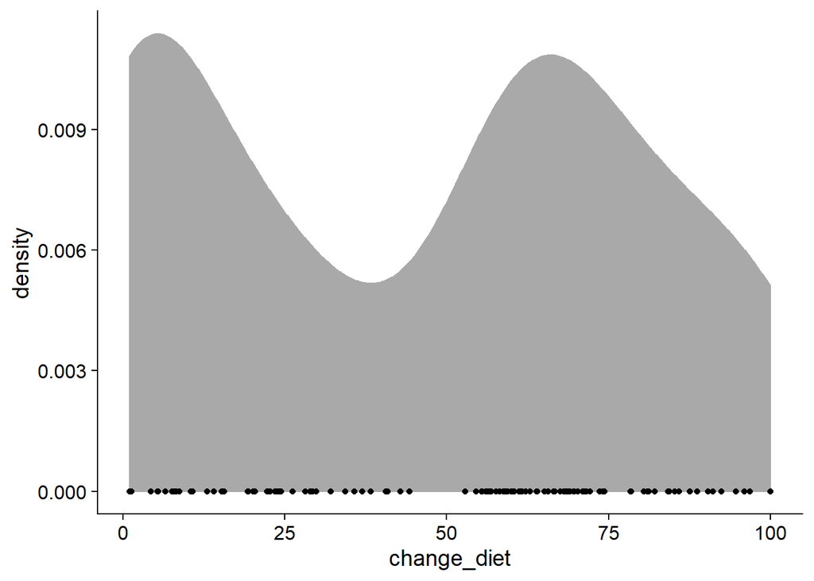

```r
# attitudes toward eating meat
describe_visualize(
  working_file,
  attitude_meat,
  FALSE,
  TRUE
)
```

```
## [[1]]
##
##
##                            x
## -------------  -------------
## nbr.val         1.660000e+02
## nbr.null        0.000000e+00
## nbr.na          0.000000e+00
## min             1.000000e+00
## max             1.000000e+02
## range           9.900000e+01
## sum             1.241726e+04
## median          8.140500e+01
## mean            7.480277e+01
## SE.mean         2.042682e+00
## CI.mean.0.95    4.033165e+00
## var             6.926433e+02
## std.dev         2.631812e+01
## coef.var        3.518335e-01
##
## [[2]]
```

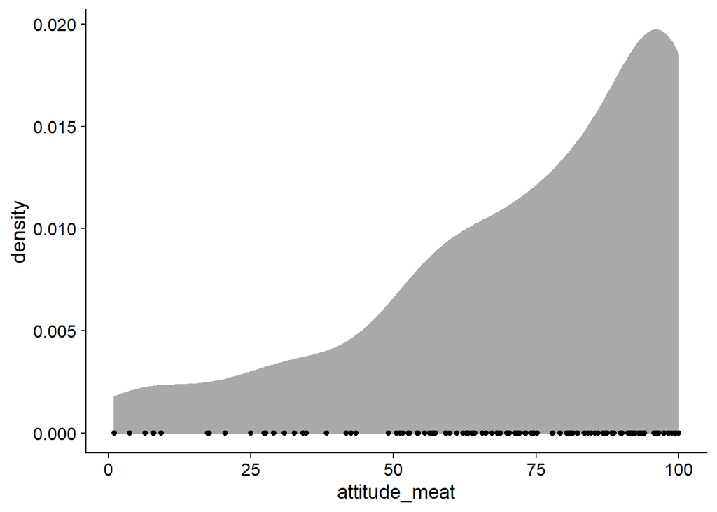

```r
# attitudes toward vegan food
describe_visualize(
  working_file,
  attitude_vegan,
  FALSE,
  TRUE
)
```

```
## [[1]]
##
##
##                            x
## -------------  -------------
## nbr.val          166.0000000
## nbr.null           0.0000000
## nbr.na             0.0000000
## min                1.0000000
## max              100.0000000
## range             99.0000000
## sum             9025.8000000
## median            56.5650000
## mean              54.3722892
## SE.mean            2.1154573
## CI.mean.0.95       4.1768554
## var              742.8764941
## std.dev           27.2557608
## coef.var           0.5012804
##
## [[2]]
```

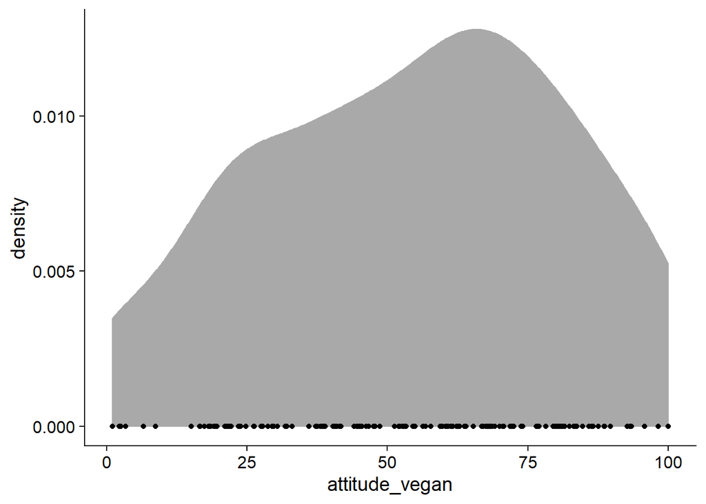

```r
# attitude toward plant-based food
describe_visualize(
  working_file,
  attitude_pb,
  FALSE,
  TRUE
)
```

```
## [[1]]
##
##
##                            x
## -------------  -------------
## nbr.val          166.0000000
## nbr.null           0.0000000
## nbr.na             0.0000000
## min                1.0000000
## max              100.0000000
## range             99.0000000
## sum             9886.2600000
## median            62.3500000
## mean              59.5557831
## SE.mean            1.9879785
## CI.mean.0.95       3.9251555
## var              656.0417288
## std.dev           25.6133116
## coef.var           0.4300726
##
## [[2]]
```

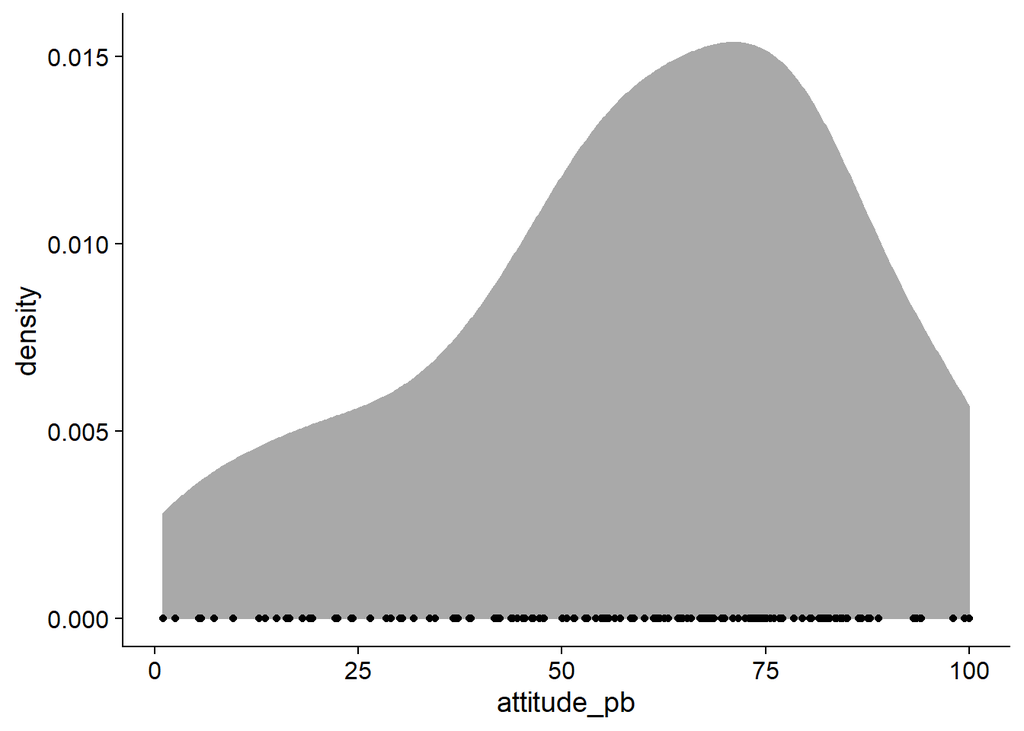

```r
# whether participants have food allergies
my_table(working_file, allergies)
```

```
## .
## yes  no
##   8 158
```

## 3.3 Ratings

Next, I visualize the ratings on attractiveness and simulations, respectively. I’ll first visualize and describe them overall, then per factor level (as in two main effects of label type and food type), and then the interaction.

### 3.1 Attractiveness

First, I inspect the overall attractiveness ratings, regardless of label or food type.

```r
describe_visualize(
  working_file %>%
    filter(measure == "attractiveness"),
  rating,
  TRUE,
  TRUE
)
```

```
## [[1]]
##
##
##                            x
## -------------  -------------
## nbr.val         6.640000e+03
## nbr.null        2.740000e+02
## nbr.na          0.000000e+00
## min             0.000000e+00
## max             1.000000e+02
## range           1.000000e+02
## sum             3.636170e+05
## median          6.070000e+01
## mean            5.476159e+01
## SE.mean         3.602866e-01
## CI.mean.0.95    7.062776e-01
## var             8.619149e+02
## std.dev         2.935839e+01
## coef.var        5.361127e-01
##
## [[2]]
```

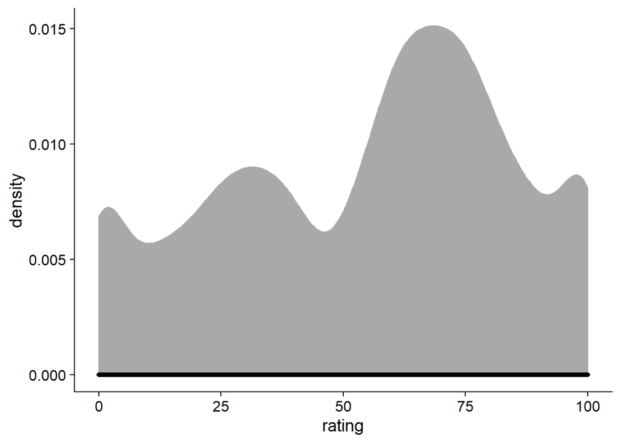

Next, a raincloud plot with ratings per label type. Doesn’t look like there’s much of a difference.

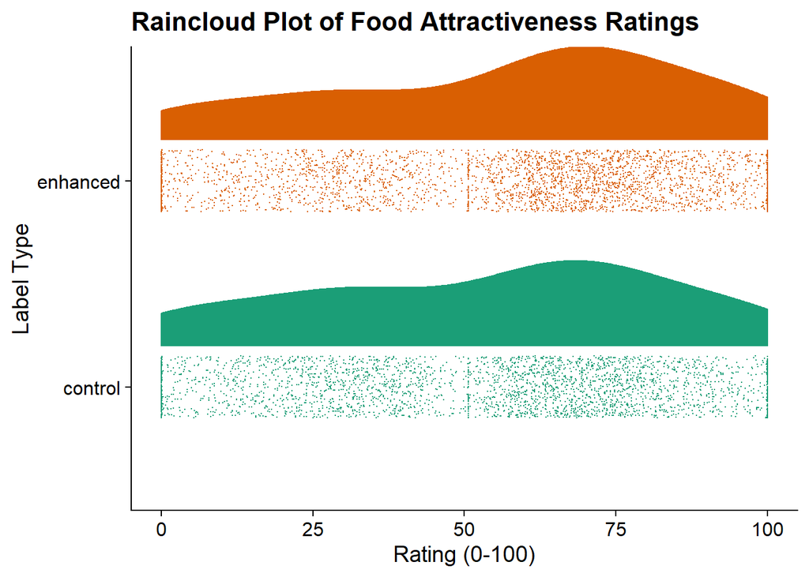

```r
rc_plot(
  working_file,
  "attractiveness",
  "rating",
  "label_type",
  "Label Type",
  "Raincloud Plot of Food Attractiveness Ratings"
  )
```

```r
working_file %>%
  filter(measure == "attractiveness") %>%
  group_by(label_type) %>%
  summarize(
    mean = mean(rating, na.rm = TRUE),
    sd = sd(rating, na.rm = TRUE)
  )
```

```
## # A tibble: 2 x 3
##   label_type  mean    sd
##   <fct>      <dbl> <dbl>
## 1 control     53.1  29.4
## 2 enhanced    56.4  29.3
```

Let’s inspect the ratings per food type. People seem to like meat-based labels more.

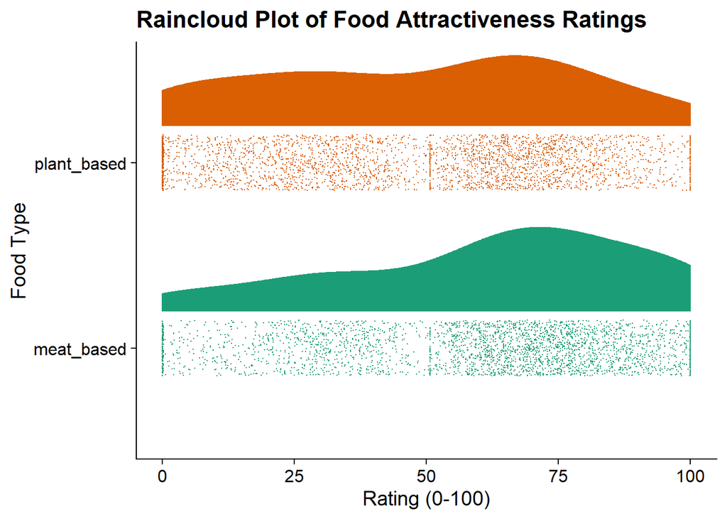

```r
rc_plot(
  working_file,
  "attractiveness",
  "rating",
  "food_type",
  "Food Type",
  "Raincloud Plot of Food Attractiveness Ratings"
  )
```

```r
working_file %>%
  filter(measure == "attractiveness") %>%
  group_by(food_type) %>%
  summarize(
    mean = mean(rating, na.rm = TRUE),
    sd = sd(rating, na.rm = TRUE)
  )
```

```
## # A tibble: 2 x 3
##   food_type    mean    sd
##   <fct>       <dbl> <dbl>
## 1 meat_based   61.3  28.0
## 2 plant_based  48.2  29.2
```

Next, I inspect the interaction of label type and food type for attractiveness ratings. The raincloud plots are not that easy to read (even if I add means with CIs), so for easier visualization I use a line plot on the aggregated means with within-subject standard error (from the `Rmisc::summarySEwithin` function).

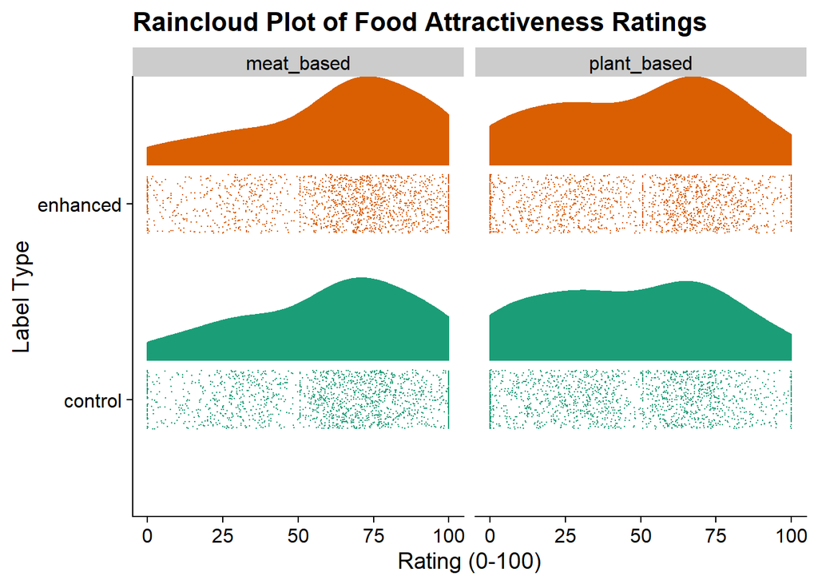

```r
rc_plot(
  working_file,
  "attractiveness",
  "rating",
  "label_type",
  "Label Type",
  "Raincloud Plot of Food Attractiveness Ratings",
  "food_type"
  )
```

```r
# get summary statistics
summary_attr <-
  summarySEwithin(
    data = working_file %>%
      filter(measure == "attractiveness") %>%
      group_by(pp, label_type, food_type) %>%
      summarize(rating = mean(rating, na.rm = TRUE)),
    measurevar = "rating",
    withinvars = c("label_type", "food_type"),
    idvar = "pp"
  )

# have a look at means and SDs
summary_attr
```

```
##   label_type   food_type   N   rating       sd        se       ci
## 1    control  meat_based 166 59.78544 11.93978 0.9267069 1.829732
## 2    control plant_based 166 46.40062 11.97610 0.9295257 1.835298
## 3   enhanced  meat_based 166 62.87654 11.57998 0.8987805 1.774593
## 4   enhanced plant_based 166 49.98378 10.98582 0.8526650 1.683541
```

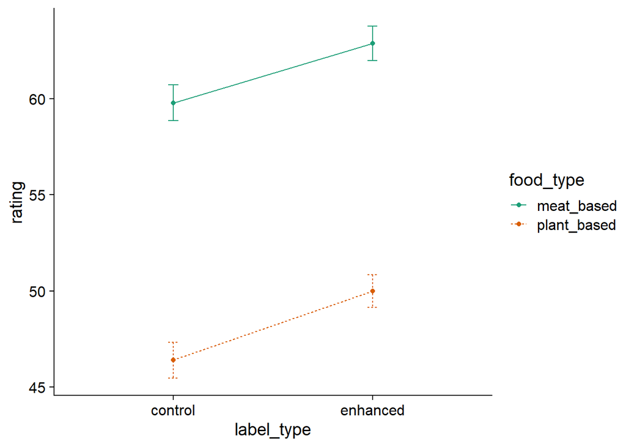

```r
# line graph
line_plot(
  summary_attr,
  "label_type",
  rating,
  "food_type"
)
```

### 3.2 Simulations

First, I inspect the overall simulations ratings, regardless of label or food type.

```r
describe_visualize(
  working_file %>%
    filter(measure == "simulations"),
  rating,
  TRUE,
  TRUE
)
```

```
## [[1]]
##
##
##                            x
## -------------  -------------
## nbr.val         6.638000e+03
## nbr.null        1.070000e+02
## nbr.na          2.000000e+00
## min             0.000000e+00
## max             1.000000e+02
## range           1.000000e+02
## sum             3.915712e+05
## median          6.394000e+01
## mean            5.898934e+01
## SE.mean         3.410187e-01
## CI.mean.0.95    6.685062e-01
## var             7.719578e+02
## std.dev         2.778413e+01
## coef.var        4.710026e-01
##
## [[2]]
```

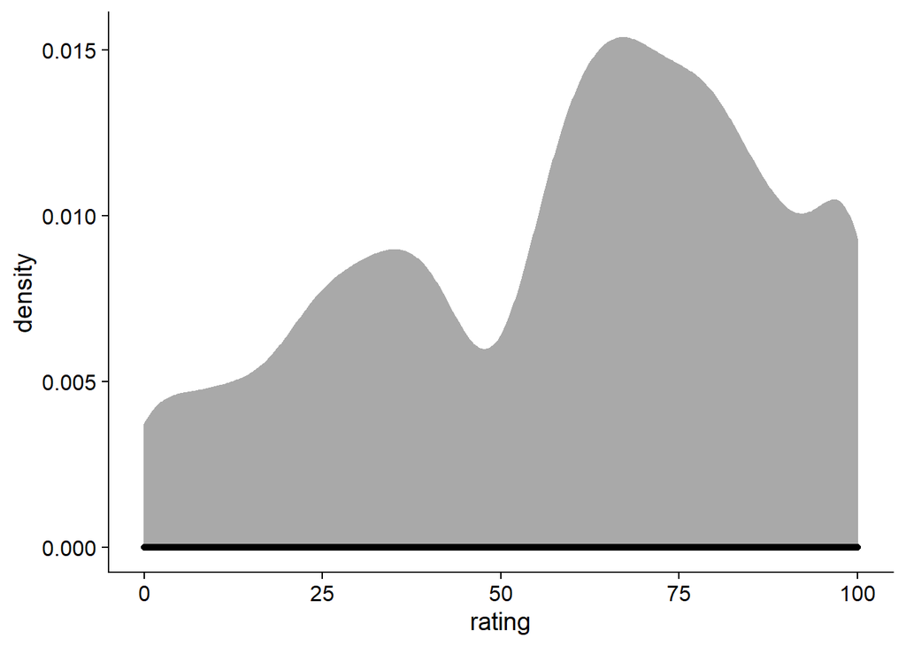

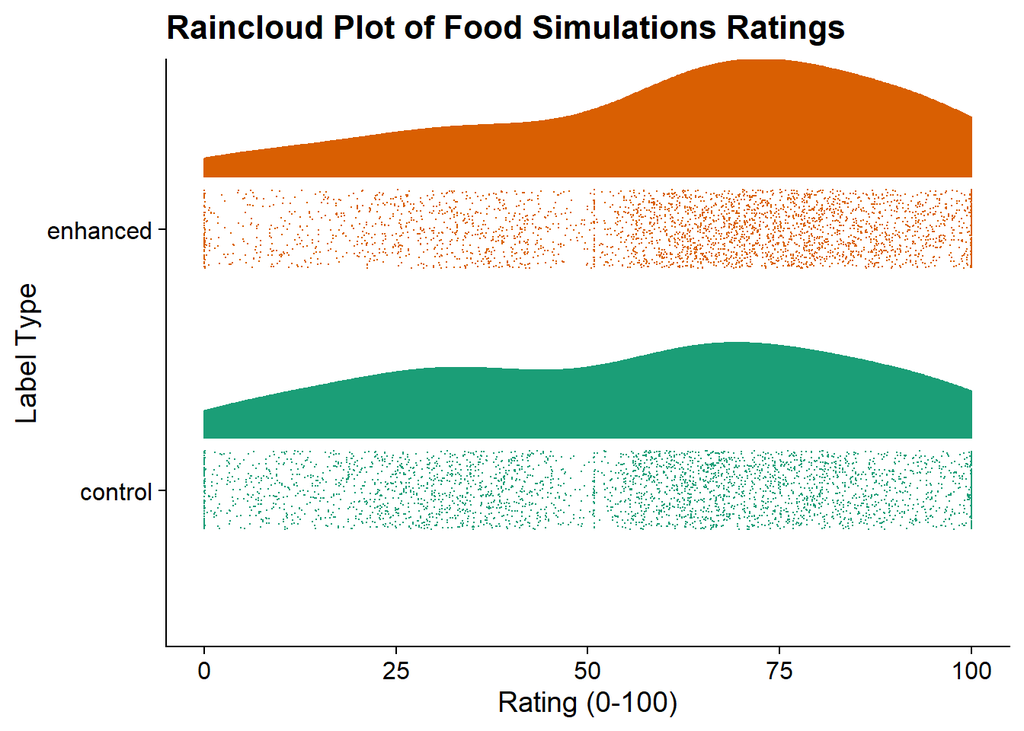

```r
rc_plot(
  working_file,
  "simulations",
  "rating",
  "label_type",
  "Label Type",
  "Raincloud Plot of Food Simulations Ratings"
  )
```

```r
working_file %>%
  filter(measure == "simulations") %>%
  group_by(label_type) %>%
  summarize(
    mean = mean(rating, na.rm = TRUE),
    sd = sd(rating, na.rm = TRUE)
  )
```

```
## # A tibble: 2 x 3
##   label_type  mean    sd
##   <fct>      <dbl> <dbl>
## 1 control     55.5  28.4
## 2 enhanced    62.5  26.7
```

Let’s inspect the ratings per food type. People seem to simulate more with meat-based labels.

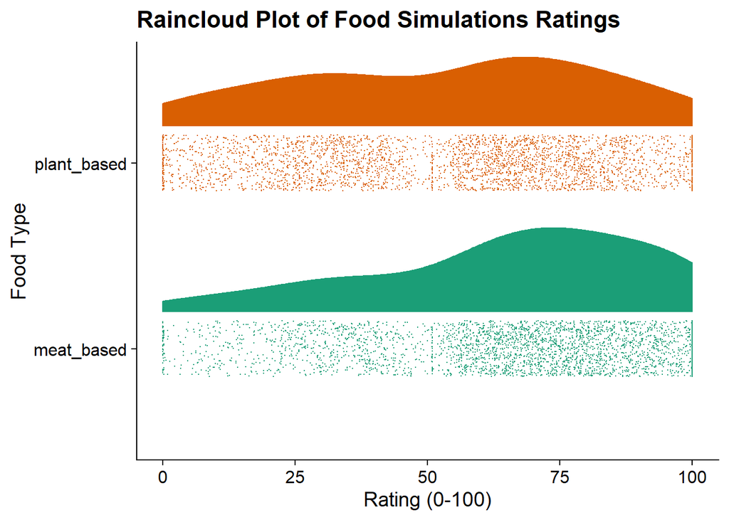

```r
rc_plot(
  working_file,
  "simulations",
  "rating",
  "food_type",
  "Food Type",
  "Raincloud Plot of Food Simulations Ratings"
  )
```

```r
working_file %>%
  filter(measure == "simulations") %>%
  group_by(food_type) %>%
  summarize(
    mean = mean(rating, na.rm = TRUE),
    sd = sd(rating, na.rm = TRUE)
  )
```

```
## # A tibble: 2 x 3
##   food_type    mean    sd
##   <fct>       <dbl> <dbl>
## 1 meat_based   64.9  26.0
## 2 plant_based  53.1  28.2
```

Next, I inspect the interaction of label type and food type for simulations ratings with rainclouds and line graphs.

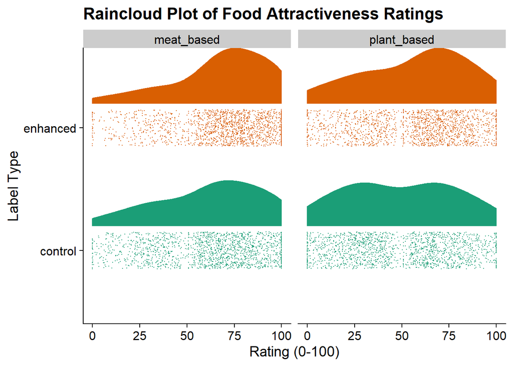

```r
rc_plot(
  working_file,
  "simulations",
  "rating",
  "label_type",
  "Label Type",
  "Raincloud Plot of Food Attractiveness Ratings",
  "food_type"
  )
```

```r
# get summary statistics
summary_sim <-
  summarySEwithin(
    data = working_file %>%
      filter(measure == "simulations") %>%
      group_by(pp, label_type, food_type) %>%
      summarize(rating = mean(rating, na.rm = TRUE)),
    measurevar = "rating",
    withinvars = c("label_type", "food_type"),
    idvar = "pp"
  )

# have a look at Ms and SDs
summary_sim
```

```
##   label_type   food_type   N   rating       sd        se       ci
## 1    control  meat_based 166 61.85078 11.84391 0.9192660 1.815041
## 2    control plant_based 166 49.09478 11.15353 0.8656821 1.709242
## 3   enhanced  meat_based 166 67.95105 11.06950 0.8591596 1.696364
## 4   enhanced plant_based 166 57.05902 12.05469 0.9356255 1.847342
```

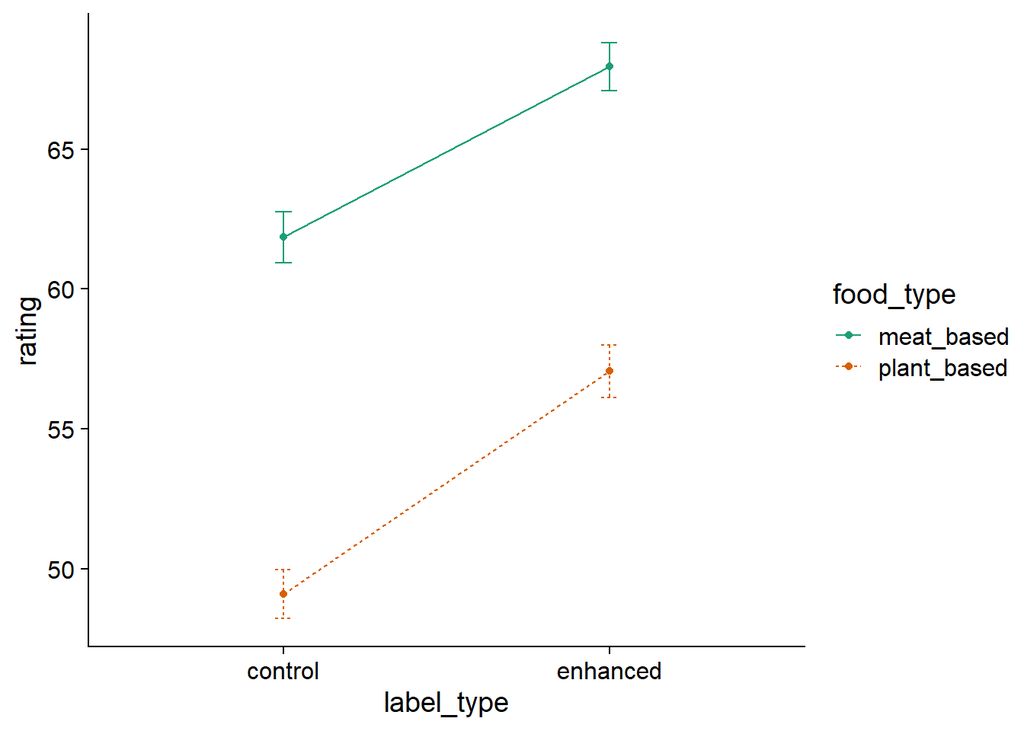

```r
# line graph
line_plot(
  summary_sim,
  "label_type",
  rating,
  "food_type"
)
```

# 4. Analysis

I now move to the actual analysis. I will structure the analysis section per hypothesis, and each hypothesis with a confirmatory/preregistered and an exploratory sub-section. I will note and explain deviations from the preregistrations wherever applicable. After the hypothesis sections, I’ll also describe exploratory results.

## 4.1 H1: Main effect of food label

The preregistered hypothesis reads as follows: >>Simulation and attractiveness will be higher for foods with enhanced compared to neutral labels.

### 4.1.1 Confirmatory

I’ll start with confirmatory model. Note that the preregistration was imprecise when saying that we will predict the outcome with food type and label type. It actually means controlling for food **item** as random effect. Thus, we specify a model with maximal effects.

Before we can do that, we need to add the individual food item as a factor to the data set. As of now, we only have the food type plus a stimulus number, which together create 40 unique food items. I’ll add them here; for a full description, see the OSM materials.

```r
# file that contains the foods
food_items <-
  read_csv(
    here("data", "food_items.csv"),
    col_types = list(
      col_factor(levels = NULL),
      col_number(),
      col_factor(levels = NULL)
    )
  )

head(food_items, n = 5)
```

```
## # A tibble: 5 x 3
##   food_type  stimulus_no food
##   <fct>            <dbl> <fct>
## 1 meat_based           1 chicken_balti
## 2 meat_based           2 pepperoni_pizza
## 3 meat_based           3 empanadas
## 4 meat_based           4 steak_pie
## 5 meat_based           5 pasta_bake
```

```r
working_file <-
  working_file %>%
  left_join(
    .,
    food_items,
    by = c("food_type",
           "stimulus_no")
  ) %>%
  select(
    pp:stimulus_no,
    food,
    everything()
  )
```

#### Simulations

Construct the main effects model: predict simulations by label type. Because we’re only interested in the main effects, I’ll use dummy coding for the predictor; we only have two levels and Type 2 or 3 sums of Squares will be the same. The model converges without problems.

```r
# set contrasts
options(contrasts = c("contr.treatment", "contr.poly"))

# construct model
h1_sim <- lme4::lmer(
  rating ~
    label_type +
    (1 + label_type | pp) +
    (1 + label_type | food),
  working_file %>%
    filter(measure == "simulations")
)

# inspect model
summary(h1_sim)
```

```
## Linear mixed model fit by REML ['lmerMod']
## Formula: rating ~ label_type + (1 + label_type | pp) + (1 + label_type |
##     food)
##    Data: working_file %>% filter(measure == "simulations")
##
## REML criterion at convergence: 61175.9
##
## Scaled residuals:
##     Min      1Q  Median      3Q     Max
## -3.4229 -0.6460  0.1250  0.6867  2.6661
##
## Random effects:
##  Groups   Name               Variance Std.Dev. Corr
##  pp       (Intercept)        199.15   14.112
##           label_typeenhanced 102.04   10.101   -0.56
##  food     (Intercept)         70.54    8.399
##           label_typeenhanced  15.20    3.899   -0.42
##  Residual                    528.00   22.978
## Number of obs: 6638, groups:  pp, 166; food, 40
##
## Fixed effects:
##                    Estimate Std. Error t value
## (Intercept)          55.480      1.767  31.398
## label_typeenhanced    7.018      1.146   6.124
##
## Correlation of Fixed Effects:
##             (Intr)
## lbl_typnhnc -0.486
```

Now let’s inspect model diagnostics. The residuals look normally distributed; the proportion of large residuals is fine; the Q-Q-plot also looks fine.

However, there are clear cut-offs in the predicted vs. residuals plot. That’s because the outcome variable has (0 | 100) bounds. For example, a fitted value of 50 can be off by a maximum of -50 or 50, not lower or higher. Usually, this pattern happens with binomial distributions. However, I don’t think this would be appropriate here: a) the residuals are normally distributed; b) I would argue that a 100 rating slider is conceptually rather different than a proportion (I wouldn’t know how to count successes and failures for a binomial distribution). Therefore, I will maintain the linear model, because I believe it makes sense conceptually and displays decent fit.

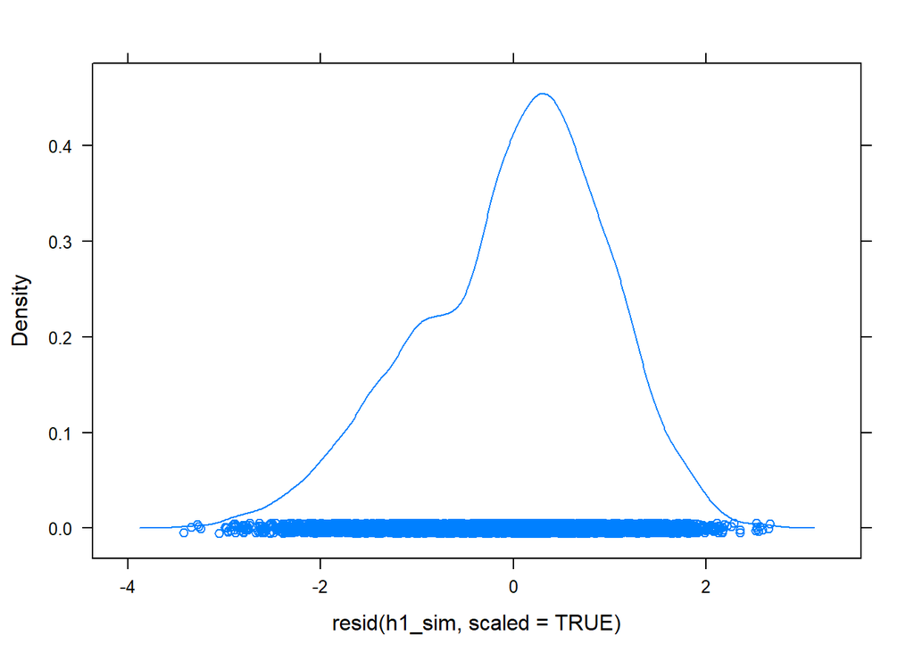

```r
# inspect standardized residuals
densityplot(resid(h1_sim, scaled = TRUE))
```

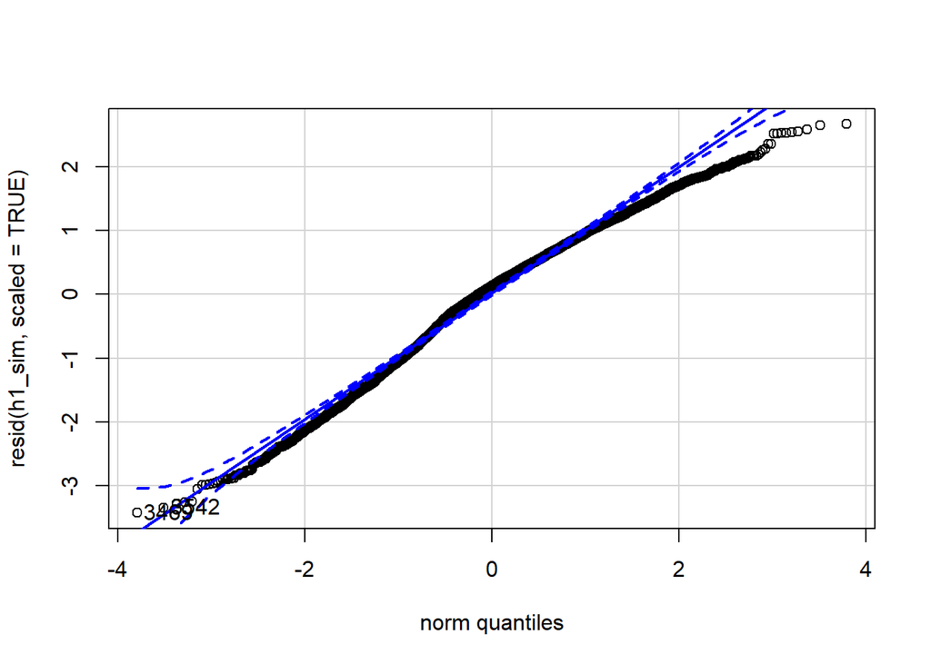

```
## [1] 3469 3542
```

```r
# q-q plot
car::qqPlot(resid(h1_sim, scaled = TRUE))
```

```r
# proportion of outliers
sum(abs(resid(h1_sim, scaled = TRUE)) > 2) / length(resid(h1_sim))
```

```
## [1] 0.0375113
```

```r
sum(abs(resid(h1_sim, scaled = TRUE)) > 2.5) / length(resid(h1_sim))
```

```
## [1] 0.0103947
```

```r
sum(abs(resid(h1_sim, scaled = TRUE)) > 3) / length(resid(h1_sim))
```

```
## [1] 0.0009038867
```

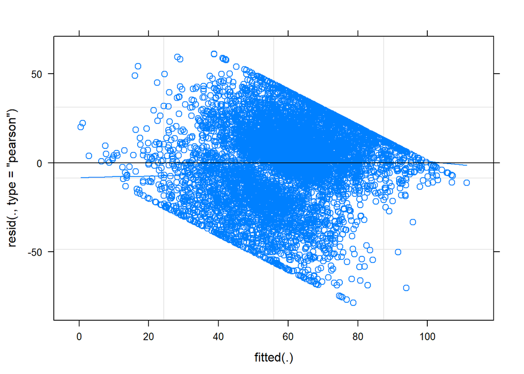

```r
# plot the fitted vs. the residuals (to check for homo/heteroskedasticity) with added smoothed line.
plot(h1_sim, type = c('p', 'smooth'))
```

```r
# get p-value
h1_sim_p <-
  mixed(
    rating ~
    label_type +
    (1 + label_type | pp) +
    (1 + label_type | food),
    working_file %>%
      filter(measure == "simulations"),
    type = 3,
    method = "S",
    check_contrasts = FALSE
  )
```

```
## Fitting one lmer() model. [DONE]
## Calculating p-values. [DONE]
```

```r
# what is it
summary(h1_sim_p)
```

```
## Linear mixed model fit by REML. t-tests use Satterthwaite's method [
## lmerModLmerTest]
## Formula: rating ~ label_type + (1 + label_type | pp) + (1 + label_type |
##     food)
##    Data: data
##
## REML criterion at convergence: 61175.9
##
## Scaled residuals:
##     Min      1Q  Median      3Q     Max
## -3.4229 -0.6460  0.1250  0.6867  2.6661
##
## Random effects:
##  Groups   Name               Variance Std.Dev. Corr
##  pp       (Intercept)        199.15   14.112
##           label_typeenhanced 102.04   10.101   -0.56
##  food     (Intercept)         70.54    8.399
##           label_typeenhanced  15.20    3.899   -0.42
##  Residual                    528.00   22.978
## Number of obs: 6638, groups:  pp, 166; food, 40
##
## Fixed effects:
##                    Estimate Std. Error     df t value Pr(>|t|)
## (Intercept)          55.480      1.767 91.800  31.398  < 2e-16 ***
## label_typeenhanced    7.018      1.146 95.131   6.124 2.04e-08 ***
## ---
## Signif. codes:  0 '***' 0.001 '**' 0.01 '*' 0.05 '.' 0.1 ' ' 1
##
## Correlation of Fixed Effects:
##             (Intr)
## lbl_typnhnc -0.486
```